# Staying or Staying

- Show All Code
- Hide All Code
- View Source

PSY 120L Reproducible Analysis Report

Author

Shanelle Jeanty

Published

June 7, 2026

## About This Report

This report documents the complete workflow that we used to conduct our research project examining the relationship between attachment styles and commitment in romantic relationships. The report provides information about the study design, data preparation, statistical analyses, and results. All analyses were conducted in R, and the report was generated using Quarto. ## Study Overview This study examined whether the way a relationship begins (online versus in person) influences an individual’s willingness to commit and whether attachment style plays a role in that relationship. Attachment Theory suggests that people with anxious or avoidant attachment styles may have more difficulty with intimacy and long-term commitment. We also drew on the Sunk Cost Fallacy, which proposes that people are more likely to stay committed to a relationship when they feel they have invested significant time and effort into it. Previous research on relationship initiation and commitment has found mixed results, and few studies have looked at how both attachment style and the context of relationship initiation work together to influence commitment. This study aims to fill that gap by exploring the combined effects of these factors on relationship commitment. *dont change this chunk*

## Setup and Software Environment

This section loads the R packages used for data wrangling, scale construction, reliability analysis, ANOVA modeling, and visualization. These tools support the reproducible workflow used to analyze the relationship between dating initiation context, attachment style, and willingness to commit. **Load Packages**

```r
library(tidyverse)  # data manipulation + plotting
library(psych)      # scale construction + reliability
library(afex)       # ANOVA models + effect sizes
library(emmeans)    # estimated marginal means + confidence intervals
```

## Data Source and Analysis Dataset

The dataset was imported from the project data folder and saved as study_raw so that the original data remained unchanged throughout the report.

A smaller analysis dataset was then created for the current analyses. This dataset retained the experimental condition variable, demographic variables, Commitment Level Subscale items, and ECR-S attachment items needed for variable preparation and the primary analyses. ### Import Dataset

```r
study_raw <- read_csv("data/staying_straying_data.csv")
```

### Check Imported Dataset

```r
dim(study_raw)
```

```
[1] 57 27
```

```r
names(study_raw)
```

```
 [1] "ResponseId"          "DistributionChannel" "Consent"
 [4] "Commit_1"            "Commit_2"            "Commit_3"
 [7] "Commit_4"            "Commit_5"            "Commit_6"
[10] "Commit_7"            "Commit_8"            "ECRS_1"
[13] "ECRS_2"              "ECRS_3"              "ECRS_4"
[16] "ECRS_5"              "ECRS_6"              "ECRS_7"
[19] "ECRS_8"              "ECRS_9"              "ECRS_10"
[22] "ECRS_11"             "ECRS_12"             "zodiac"
[25] "age"                 "gender"              "condition"
```

```r
head(study_raw)
```

```
# A tibble: 6 × 27
  ResponseId     DistributionChannel Consent Commit_1 Commit_2 Commit_3 Commit_4
  <chr>          <chr>                 <dbl>    <dbl>    <dbl>    <dbl>    <dbl>
1 R_33jar6hZfXT… email                     1        7        8        6        3
2 R_3YTqJ9eK2Nl… email                     1        9        9        9        1
3 R_5Gkbu0b4OR5… email                     1        9        9        5        3
4 R_7E0Dy5fon0s… email                     1        9        9        8        1
5 R_5EEjq5YU90w… email                     1        6        6        6        1
6 R_1KVKyaSSdhL… email                     1        6        7        7        2
# ℹ 20 more variables: Commit_5 <dbl>, Commit_6 <dbl>, Commit_7 <dbl>,
#   Commit_8 <dbl>, ECRS_1 <dbl>, ECRS_2 <dbl>, ECRS_3 <dbl>, ECRS_4 <dbl>,
#   ECRS_5 <dbl>, ECRS_6 <dbl>, ECRS_7 <dbl>, ECRS_8 <dbl>, ECRS_9 <dbl>,
#   ECRS_10 <dbl>, ECRS_11 <dbl>, ECRS_12 <dbl>, zodiac <dbl>, age <dbl>,
#   gender <dbl>, condition <dbl>
```

The imported dataset contained 57 participants and 27 variables. Reviewing the dataset dimensions and variable names confirmed that the data were imported correctly and included the demographic, experimental condition, commitment, and attachment variables needed for the study. ### Create Analysis Dataset

```r
study_vars <- c(
  "condition", "zodiac", "age", "gender",

  "Commit_1", "Commit_2", "Commit_3", "Commit_4",
  "Commit_5", "Commit_6", "Commit_7", "Commit_8",
  "ECRS_1", "ECRS_2", "ECRS_3", "ECRS_4", "ECRS_5", "ECRS_6",
  "ECRS_7", "ECRS_8", "ECRS_9", "ECRS_10", "ECRS_11", "ECRS_12"

)



study_data <- study_raw %>%
  select(all_of(study_vars)) %>%
  mutate(
    across(everything(), as.numeric)
  )
```

### Check Analysis Dataset

```r
length(study_vars)
```

```
[1] 24
```

```r
dim(study_data)
```

```
[1] 57 24
```

```r
names(study_data)
```

```
 [1] "condition" "zodiac"    "age"       "gender"    "Commit_1"  "Commit_2"
 [7] "Commit_3"  "Commit_4"  "Commit_5"  "Commit_6"  "Commit_7"  "Commit_8"
[13] "ECRS_1"    "ECRS_2"    "ECRS_3"    "ECRS_4"    "ECRS_5"    "ECRS_6"
[19] "ECRS_7"    "ECRS_8"    "ECRS_9"    "ECRS_10"   "ECRS_11"   "ECRS_12"
```

## The analysis dataset was checked to confirm that the intended variables were retained for the current study. The output shows that the dataset contained 57 participants and 24 variables, including the experimental condition, demographic variables, and the commitment and attachment scale items used in the analyses.

## This section prepares the variables used in the primary analyses. The original imported dataset was left unchanged; all prepared variables were created in the working analysis dataset, study_data, including the experimental condition, reverse-coded items, scale scores, and attachment groups.

### Prepare Participant ID and Experimental Condition

```r
study_data <- study_data %>%
  mutate(
    id = row_number(),
    condition = factor(
      condition,
      levels = c(0, 1),
      labels = c("Online", "In Person")
    )
  )
```

A unique participant identification variable was created for use in the analyses. The experimental condition variable was also recoded as a factor, with participants categorized into either the Online or In Person relationship initiation condition. ### Check Experimental Condition Coding

```r
study_data %>%
  count(condition) %>%
  knitr::kable(
    col.names = c("Condition", "n")
  )
```

| Condition | n |
| --- | --- |
| Online | 28 |
| In Person | 25 |
| NA | 4 |

The experimental condition variable was checked to confirm that participants were correctly classified into the Online and In Person relationship initiation conditions. The sample included 28 participants in the Online condition, 25 participants in the In Person condition, and 4 participants with missing condition data. ### Check Prepared Analysis Dataset

```r
dim(study_data)
```

```
[1] 57 25
```

```r
names(study_data)
```

```
 [1] "condition" "zodiac"    "age"       "gender"    "Commit_1"  "Commit_2"
 [7] "Commit_3"  "Commit_4"  "Commit_5"  "Commit_6"  "Commit_7"  "Commit_8"
[13] "ECRS_1"    "ECRS_2"    "ECRS_3"    "ECRS_4"    "ECRS_5"    "ECRS_6"
[19] "ECRS_7"    "ECRS_8"    "ECRS_9"    "ECRS_10"   "ECRS_11"   "ECRS_12"
[25] "id"
```

## The prepared analysis dataset was checked to confirm that the new variables were successfully created and retained. The dataset contained 57 participants and 25 variables, including the participant ID variable and the recoded experimental condition.

### Reverse-Code Scale Items

Items from the ECR-S and Commitment Level Subscale were reverse-coded before calculating scale scores. Reverse coding ensured that higher values consistently reflected higher levels of the intended constructs across each measure.

```r
study_data <- study_data %>%
  mutate(
    ECRS_1r = 8 - ECRS_1,
    ECRS_5r = 8 - ECRS_5,
    ECRS_8r = 8 - ECRS_8,
    ECRS_9r = 8 - ECRS_9,


    Commit_4r = 10 - Commit_4,
    Commit_5r = 10 - Commit_5,
    Commit_8r = 10 - Commit_8

  )
```

### Check Reverse Coding

```r
study_data %>%
  select(ECRS_1, ECRS_1r, Commit_4, Commit_4r) %>%
  head(10) %>%
  knitr::kable()
```

| ECRS_1 | ECRS_1r | Commit_4 | Commit_4r |
| --- | --- | --- | --- |
| 6 | 2 | 3 | 7 |
| 7 | 1 | 1 | 9 |
| 5 | 3 | 3 | 7 |
| 7 | 1 | 1 | 9 |
| 7 | 1 | 1 | 9 |
| 6 | 2 | 2 | 8 |
| 6 | 2 | 2 | 8 |
| 7 | 1 | 1 | 9 |
| 5 | 3 | 2 | 8 |
| 7 | 1 | 2 | 8 |

### Create Scale Scores

Scale scores were created for overall attachment insecurity, attachment anxiety, attachment avoidance, and willingness to commit by averaging the appropriate questionnaire items. These composite variables were used in the primary analyses to examine the relationships among attachment style, relationship initiation context, and commitment.

```r
# Define ECR-S total attachment insecurity items
ECRS_items <- c(
  "ECRS_1r", "ECRS_2", "ECRS_3", "ECRS_4", "ECRS_5r", "ECRS_6",
  "ECRS_7", "ECRS_8r", "ECRS_9r", "ECRS_10", "ECRS_11", "ECRS_12"
)

# Define ECR-S anxiety items
ECRS_anxiety_items <- c(
  "ECRS_2", "ECRS_4", "ECRS_6", "ECRS_8r", "ECRS_10", "ECRS_12"
)

# Define ECR-S avoidance items
ECRS_avoidance_items <- c(
  "ECRS_1r", "ECRS_3", "ECRS_5r", "ECRS_7", "ECRS_9r", "ECRS_11"
)

# Define commitment items
commitment_items <- c(
  "Commit_1", "Commit_2", "Commit_3", "Commit_4r",
  "Commit_5r", "Commit_6", "Commit_7", "Commit_8r"
)

# Create scale scores
study_data <- study_data %>%
  mutate(
    ECRS_scale = rowMeans(across(all_of(ECRS_items)), na.rm = TRUE),
    ECRS_anxiety = rowMeans(across(all_of(ECRS_anxiety_items)), na.rm = TRUE),
    ECRS_avoidance = rowMeans(across(all_of(ECRS_avoidance_items)), na.rm = TRUE),
    commitment = rowMeans(across(all_of(commitment_items)), na.rm = TRUE)
  )
```

### Check Scale Scores

```r
study_data %>%
  select(
    ECRS_scale,
    ECRS_anxiety,
    ECRS_avoidance,
    commitment
  ) %>%
  summary()
```

```
   ECRS_scale     ECRS_anxiety   ECRS_avoidance    commitment
 Min.   :1.500   Min.   :1.667   Min.   :1.000   Min.   :4.000
 1st Qu.:2.833   1st Qu.:3.333   1st Qu.:2.000   1st Qu.:6.000
 Median :3.417   Median :4.000   Median :2.583   Median :6.875
 Mean   :3.330   Mean   :4.041   Mean   :2.590   Mean   :6.765
 3rd Qu.:3.750   3rd Qu.:4.667   3rd Qu.:3.167   3rd Qu.:7.625
 Max.   :4.917   Max.   :5.833   Max.   :4.833   Max.   :9.000
 NA's   :8       NA's   :8       NA's   :9       NA's   :8
```

```r
study_data %>%
  summarise(
    ECRS_scale_missing = mean(is.na(ECRS_scale)),
    ECRS_anxiety_missing = mean(is.na(ECRS_anxiety)),
    ECRS_avoidance_missing = mean(is.na(ECRS_avoidance)),
    commitment_missing = mean(is.na(commitment))
  ) %>%
  knitr::kable()
```

| ECRS_scale_missing | ECRS_anxiety_missing | ECRS_avoidance_missing | commitment_missing |
| --- | --- | --- | --- |
| 0.1403509 | 0.1403509 | 0.1578947 | 0.1403509 |

## The scale scores were checked to confirm that the composite variables were created correctly. Summary statistics and missing data were examined for the overall attachment insecurity, attachment anxiety, attachment avoidance, and commitment scales before conducting the primary analyses.

### Create Attachment Groups

This section computes median splits for attachment-related variables (overall ECR-S score, anxiety, and avoidance) in order to create categorical “low” and “high” groups. Participants scoring at or below the median are classified as “Low,” while those above the median are classified as “High.” These grouped variables are then used for subsequent comparative analyses.

```r
# Compute median ECR-S scores
ECRS_median <- median(study_data$ECRS_scale, na.rm = TRUE)
ECRS_anxiety_median <- median(study_data$ECRS_anxiety, na.rm = TRUE)
ECRS_avoidance_median <- median(study_data$ECRS_avoidance, na.rm = TRUE)

# Create low/high attachment groups
study_data <- study_data %>%
  mutate(
    ECRS_msplit = if_else(ECRS_scale <= ECRS_median, "Low", "High"),
    ECRS_msplit = factor(ECRS_msplit, levels = c("Low", "High")),

    ECRS_anxiety_msplit = if_else(ECRS_anxiety <= ECRS_anxiety_median, "Low", "High"),
    ECRS_anxiety_msplit = factor(ECRS_anxiety_msplit, levels = c("Low", "High")),

    ECRS_avoidance_msplit = if_else(ECRS_avoidance <= ECRS_avoidance_median, "Low", "High"),
    ECRS_avoidance_msplit = factor(ECRS_avoidance_msplit, levels = c("Low", "High"))
  )

# Print medians
ECRS_median
```

```
[1] 3.416667
```

```r
ECRS_anxiety_median
```

```
[1] 4
```

```r
ECRS_avoidance_median
```

```
[1] 2.583333
```

```r
# Check group sizes
study_data %>%
  count(ECRS_msplit) %>%
  knitr::kable()
```

| ECRS_msplit | n |
| --- | --- |
| Low | 27 |
| High | 22 |
| NA | 8 |

```r
study_data %>%
  count(ECRS_anxiety_msplit) %>%
  knitr::kable()
```

| ECRS_anxiety_msplit | n |
| --- | --- |
| Low | 26 |
| High | 23 |
| NA | 8 |

```r
study_data %>%
  count(ECRS_avoidance_msplit) %>%
  knitr::kable()
```

| ECRS_avoidance_msplit | n |
| --- | --- |
| Low | 24 |
| High | 24 |
| NA | 9 |

## A median split procedure was used to categorize participants into “low” and “high” groups for overall attachment (ECR-S), attachment anxiety, and attachment avoidance. Each variable was dichotomized based on its median score to create categorical variables for subsequent analyses.

### Check Scale Reliability

```r
# Create item-only data frames for each multi-item rating scale
ECRS_item_df <- study_data %>%
  select(all_of(ECRS_items))

ECRS_anxiety_item_df <- study_data %>%
  select(all_of(ECRS_anxiety_items))

ECRS_avoidance_item_df <- study_data %>%
  select(all_of(ECRS_avoidance_items))

commitment_item_df <- study_data %>%
  select(all_of(commitment_items))

# Compute internal consistency estimates
ECRS_alpha <- psych::alpha(ECRS_item_df)
```

```
Some items ( ECRS_2 ECRS_8r ECRS_10 ECRS_12 ) were negatively correlated with the first principal component and
probably should be reversed.
To do this, run the function again with the 'check.keys=TRUE' option
```

```r
ECRS_omega <- psych::omega(ECRS_item_df, plot = FALSE)

ECRS_anxiety_alpha <- psych::alpha(ECRS_anxiety_item_df)
ECRS_anxiety_omega <- psych::omega(ECRS_anxiety_item_df, plot = FALSE)

ECRS_avoidance_alpha <- psych::alpha(ECRS_avoidance_item_df)
ECRS_avoidance_omega <- psych::omega(ECRS_avoidance_item_df, plot = FALSE)

commitment_alpha <- psych::alpha(commitment_item_df)
commitment_omega <- psych::omega(commitment_item_df, plot = FALSE)

# Print only alpha and omega coefficients
tibble(
  scale = c(
    "ECR-S Attachment Insecurity",
    "ECR-S Attachment Anxiety",
    "ECR-S Attachment Avoidance",
    "Commitment"
  ),
  alpha = c(
    ECRS_alpha$total$raw_alpha,
    ECRS_anxiety_alpha$total$raw_alpha,
    ECRS_avoidance_alpha$total$raw_alpha,
    commitment_alpha$total$raw_alpha
  ),
  omega = c(
    ECRS_omega$omega.tot,
    ECRS_anxiety_omega$omega.tot,
    ECRS_avoidance_omega$omega.tot,
    commitment_omega$omega.tot
  )
) %>%
  knitr::kable(digits = 2)
```

| scale | alpha | omega |
| --- | --- | --- |
| ECR-S Attachment Insecurity | 0.63 | 0.81 |
| ECR-S Attachment Anxiety | 0.59 | 0.62 |
| ECR-S Attachment Avoidance | 0.78 | 0.89 |
| Commitment | 0.77 | 0.89 |

## Inspection of item-level output suggested that some ECR-S items may require reverse-scoring, as they were negatively associated with the primary factor. This was flagged for verification using reverse-coding diagnostics in the scale construction phase.

## Descriptive Statistics

This section provides an overview of the key study variables prior to hypothesis testing. It includes descriptive statistics for the main scale scores as well as demographic information about the sample. ### Scale Score Descriptives

```r
study_data %>%
  select(
    ECRS_scale,
    ECRS_anxiety,
    ECRS_avoidance,
    commitment
  ) %>%
  psych::describe() %>%
  knitr::kable(digits = 2)
```

|  | vars | n | mean | sd | median | trimmed | mad | min | max | range | skew | kurtosis | se |
| --- | --- | --- | --- | --- | --- | --- | --- | --- | --- | --- | --- | --- | --- |
| ECRS_scale | 1 | 49 | 3.33 | 0.67 | 3.42 | 3.36 | 0.62 | 1.50 | 4.92 | 3.42 | -0.47 | 0.50 | 0.10 |
| ECRS_anxiety | 2 | 49 | 4.04 | 0.93 | 4.00 | 4.06 | 0.99 | 1.67 | 5.83 | 4.17 | -0.21 | -0.18 | 0.13 |
| ECRS_avoidance | 3 | 48 | 2.59 | 0.94 | 2.58 | 2.55 | 0.86 | 1.00 | 4.83 | 3.83 | 0.39 | -0.20 | 0.14 |
| commitment | 4 | 49 | 6.77 | 1.23 | 6.88 | 6.77 | 1.11 | 4.00 | 9.00 | 5.00 | -0.15 | -0.54 | 0.18 |

The table summarizes descriptive statistics for the main study variables, including attachment insecurity (ECR-S), attachment anxiety, attachment avoidance, and commitment. These values provide information about central tendency, variability, and overall score distributions across measures. ### Sample Composition by Age, Gender, and Relationship

```r
study_data %>%
  summarise(
    mean_age = mean(age, na.rm = TRUE),
    sd_age = sd(age, na.rm = TRUE),
    min_age = min(age, na.rm = TRUE),
    max_age = max(age, na.rm = TRUE)
  ) %>%
  knitr::kable(
    digits = 2,
    col.names = c("Mean", "SD", "Minimum", "Maximum"),
    caption = "Sample Age: Mean, Standard Deviation, and Range"
  )
```

Sample Age: Mean, Standard Deviation, and Range

| Mean | SD | Minimum | Maximum |
| --- | --- | --- | --- |
| 21.69 | 1.61 | 19 | 28 |

```r
study_data %>%
  count(gender) %>%
  arrange(gender) %>%
  mutate(percent = round(100 * n / sum(n), 1)) %>%
  knitr::kable(
    col.names = c("Gender", "n", "Percent"),
    caption = "Sample Composition by Gender"
  )
```

Sample Composition by Gender

| Gender | n | Percent |
| --- | --- | --- |
| 1 | 5 | 8.8 |
| 2 | 43 | 75.4 |
| NA | 9 | 15.8 |

## This section summarizes the demographic composition of the sample, including age distribution and gender breakdown. These checks help contextualize the sample characteristics used in the analyses.

## Correlations Among the DVs

This section reports correlations among the main continuous study variables, including attachment insecurity, attachment dimensions, and willingness to commit. These relationships provide preliminary insight into how the key constructs are associated prior to model testing.

```r
# Correlations for the main continuous study variables
psych::corr.test(
  study_data %>%
    select(
      ECRS_scale,
      ECRS_anxiety,
      ECRS_avoidance,
      commitment
    )
)
```

```
Call:psych::corr.test(x = study_data %>% select(ECRS_scale, ECRS_anxiety,
    ECRS_avoidance, commitment))
Correlation matrix
               ECRS_scale ECRS_anxiety ECRS_avoidance commitment
ECRS_scale           1.00         0.70           0.71      -0.27
ECRS_anxiety         0.70         1.00           0.01       0.04
ECRS_avoidance       0.71         0.01           1.00      -0.40
commitment          -0.27         0.04          -0.40       1.00
Sample Size
               ECRS_scale ECRS_anxiety ECRS_avoidance commitment
ECRS_scale             49           49             48         49
ECRS_anxiety           49           49             48         49
ECRS_avoidance         48           48             48         48
commitment             49           49             48         49
Probability values (Entries above the diagonal are adjusted for multiple tests.)
               ECRS_scale ECRS_anxiety ECRS_avoidance commitment
ECRS_scale           0.00         0.00           0.00       0.17
ECRS_anxiety         0.00         0.00           1.00       1.00
ECRS_avoidance       0.00         0.97           0.00       0.02
commitment           0.06         0.79           0.01       0.00

 To see confidence intervals of the correlations, print with the short=FALSE option
```

## This section reports the primary analyses examining whether dating initiation context (online vs. in-person), attachment style, and attachment type predict willingness to commit. A factorial design was used to test main effects and interaction effects on commitment scores.

### **Commitment Model (total ECRS split)**

```r
a1_commitment <- afex::aov_ez(
  id = "id",
  dv = "commitment",
  between = c("condition", "ECRS_msplit"),
  data = study_data
)

# Print the ANOVA table
a1_commitment
```

```
Anova Table (Type 3 tests)

Response: commitment
                 Effect    df  MSE    F  ges p.value
1             condition 1, 45 1.50 0.30 .007    .588
2           ECRS_msplit 1, 45 1.50 1.76 .038    .192
3 condition:ECRS_msplit 1, 45 1.50 0.73 .016    .397
---
Signif. codes:  0 '***' 0.001 '**' 0.01 '*' 0.05 '+' 0.1 ' ' 1
```

```r
emmeans(a1_commitment, ~ condition)
```

```
 condition emmean    SE df lower.CL upper.CL
 Online      6.82 0.234 45     6.34     7.29
 In Person   6.62 0.268 45     6.08     7.16

Results are averaged over the levels of: ECRS_msplit
Confidence level used: 0.95
```

```r
emmeans(a1_commitment, ~ ECRS_msplit)
```

```
 ECRS_msplit emmean    SE df lower.CL upper.CL
 Low           6.95 0.240 45     6.47     7.44
 High          6.48 0.263 45     5.95     7.01

Results are averaged over the levels of: condition
Confidence level used: 0.95
```

```r
emmeans(a1_commitment, ~ condition * ECRS_msplit)
```

```
 condition ECRS_msplit emmean    SE df lower.CL upper.CL
 Online    Low           7.20 0.307 45     6.59     7.82
 In Person Low           6.70 0.370 45     5.96     7.45
 Online    High          6.43 0.354 45     5.71     7.14
 In Person High          6.54 0.388 45     5.76     7.32

Confidence level used: 0.95
```

## Estimated marginal means were computed to further examine differences in willingness to commit across dating initiation condition and attachment insecurity group. Overall, commitment scores were similar across both conditions and attachment groups, and the pattern of means did not indicate strong differences between groups or a clear interaction between factors.

### **Commitment** Model (ECRS Anxiety)

The results indicated no significant interaction between dating initiation context and attachment anxiety. This suggests that the effect of relationship condition on willingness to commit did not differ based on participants’ level of attachment anxiety.

```r
# 2x2 between-subjects ANOVA predicting commitment scores
# DV: commitment
# Factors: condition and ECR-S attachment anxiety group
a2_commitment_anxiety <- afex::aov_ez(
  id = "id",
  dv = "commitment",
  between = c("condition", "ECRS_anxiety_msplit"),
  data = study_data
)

# Print the ANOVA table
a2_commitment_anxiety
```

```
Anova Table (Type 3 tests)

Response: commitment
                         Effect    df  MSE    F   ges p.value
1                     condition 1, 45 1.59 0.52  .011    .474
2           ECRS_anxiety_msplit 1, 45 1.59 0.04 <.001    .837
3 condition:ECRS_anxiety_msplit 1, 45 1.59 0.27  .006    .603
---
Signif. codes:  0 '***' 0.001 '**' 0.01 '*' 0.05 '+' 0.1 ' ' 1
```

```r
emmeans(a2_commitment_anxiety, ~ condition)
```

```
 condition emmean    SE df lower.CL upper.CL
 Online      6.87 0.238 45     6.39     7.35
 In Person   6.61 0.278 45     6.05     7.17

Results are averaged over the levels of: ECRS_anxiety_msplit
Confidence level used: 0.95
```

```r
emmeans(a2_commitment_anxiety, ~ ECRS_anxiety_msplit)
```

```
 ECRS_anxiety_msplit emmean    SE df lower.CL upper.CL
 Low                   6.78 0.248 45     6.28     7.28
 High                  6.70 0.269 45     6.16     7.24

Results are averaged over the levels of: condition
Confidence level used: 0.95
```

```r
emmeans(a2_commitment_anxiety, ~ condition * ECRS_anxiety_msplit)
```

```
 condition ECRS_anxiety_msplit emmean    SE df lower.CL upper.CL
 Online    Low                   6.81 0.337 45     6.13     7.49
 In Person Low                   6.74 0.364 45     6.01     7.47
 Online    High                  6.93 0.337 45     6.25     7.61
 In Person High                  6.47 0.420 45     5.63     7.32

Confidence level used: 0.95
```

Estimated marginal means were computed to further examine differences in willingness to commit across dating initiation condition and attachment anxiety group. Overall, commitment scores were similar across conditions and attachment anxiety groups, and the estimated means did not indicate meaningful differences or a clear interaction pattern between variables. ### **Commitment** Model (ECRS Avoidance)

A 2 × 2 ANOVA was conducted to examine whether willingness to commit differed by dating initiation condition (online vs. in-person), attachment avoidance group, and their interaction. The results showed no significant main effect of condition and no significant interaction between condition and attachment avoidance. However, a significant main effect of attachment avoidance was observed, indicating that individuals with higher avoidance reported lower willingness to commit overall.

```r
# 2x2 between-subjects ANOVA predicting commitment scores
# DV: commitment
# Factors: condition and ECR-S attachment avoidance group
a3_commitment_avoidance <- afex::aov_ez(
  id = "id",
  dv = "commitment",
  between = c("condition", "ECRS_avoidance_msplit"),
  data = study_data
)

# Print the ANOVA table
a3_commitment_avoidance
```

```
Anova Table (Type 3 tests)

Response: commitment
                           Effect    df  MSE      F   ges p.value
1                       condition 1, 44 1.40   0.59  .013    .445
2           ECRS_avoidance_msplit 1, 44 1.40 5.58 *  .112    .023
3 condition:ECRS_avoidance_msplit 1, 44 1.40   0.04 <.001    .845
---
Signif. codes:  0 '***' 0.001 '**' 0.01 '*' 0.05 '+' 0.1 ' ' 1
```

```r
emmeans(a3_commitment_avoidance, ~ condition)
```

```
 condition emmean    SE df lower.CL upper.CL
 Online      6.91 0.228 44     6.45     7.37
 In Person   6.65 0.259 44     6.12     7.17

Results are averaged over the levels of: ECRS_avoidance_msplit
Confidence level used: 0.95
```

```r
emmeans(a3_commitment_avoidance, ~ ECRS_avoidance_msplit)
```

```
 ECRS_avoidance_msplit emmean    SE df lower.CL upper.CL
 Low                     7.19 0.245 44     6.69     7.68
 High                    6.37 0.243 44     5.88     6.86

Results are averaged over the levels of: condition
Confidence level used: 0.95
```

```r
emmeans(a3_commitment_avoidance, ~ condition * ECRS_avoidance_msplit)
```

```
 condition ECRS_avoidance_msplit emmean    SE df lower.CL upper.CL
 Online    Low                     7.29 0.317 44     6.65     7.92
 In Person Low                     7.09 0.375 44     6.33     7.84
 Online    High                    6.54 0.329 44     5.88     7.20
 In Person High                    6.20 0.357 44     5.48     6.92

Confidence level used: 0.95
```

## Estimated marginal means were computed to further examine differences in willingness to commit across dating initiation condition and attachment avoidance group. The results showed generally similar commitment scores across conditions, but lower overall commitment among individuals with higher attachment avoidance. The pattern of means is consistent with the significant main effect of attachment avoidance observed in the ANOVA results.

## Figures

This section presents interaction plots illustrating the effects of dating initiation condition and attachment style on willingness to commit. The figures visualize estimated marginal means from the ANOVA models, with error bars representing 95% confidence intervals. These plots support interpretation of main effects and interaction effects across the three attachment models. ### Commitment (total ECRS) Interaction Plot

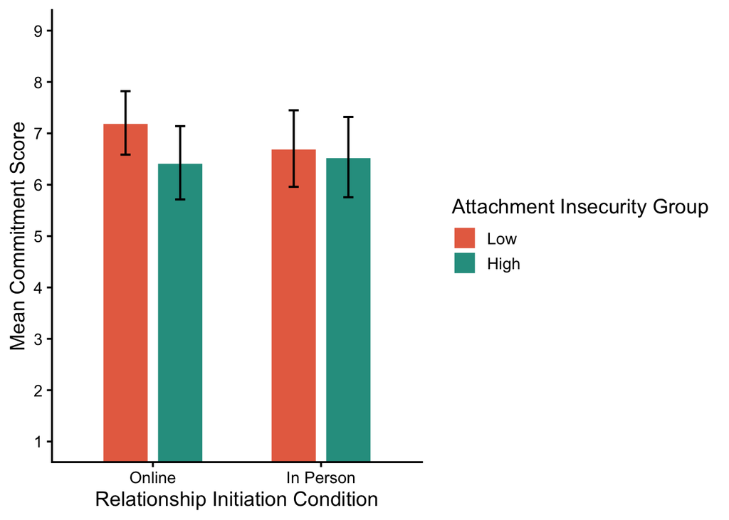

```r
p_total_ecrs_bar <- ggplot(
  as.data.frame(emmeans(a1_commitment, ~ condition * ECRS_msplit)),
  aes(
    x = condition,
    y = emmean,
    fill = ECRS_msplit
  )
) +
  geom_col(
    position = position_dodge(width = 0.65),
    width = 0.55,
    color = "white"
  ) +
  geom_errorbar(
    aes(
      ymin = lower.CL,
      ymax = upper.CL
    ),
    position = position_dodge(width = 0.65),
    width = 0.12,
    linewidth = 0.7
  ) +
  labs(
    x = "Relationship Initiation Condition",
    y = "Mean Commitment Score",
    fill = "Attachment Insecurity Group"
  ) +
  scale_fill_manual(
    values = c(
      "Low" = "#E76F51", # YOU CAN CHANGE THESE TWO HEX VALUES TO MATCH YOUR POSTER!
      "High" = "#2A9D8F"
    )
  ) +
  scale_y_continuous(
    breaks = seq(1, 9, 1)
  ) +
  coord_cartesian(
    ylim = c(1, 9)
  ) +
  theme_classic(
    base_size = 14
  )

p_total_ecrs_bar
```

## The figure shows estimated commitment scores by relationship initiation condition (online vs. in-person) and attachment insecurity group (low vs. high). Error bars represent 95% confidence intervals.

### Commitment (ECRS Anxiety) Interaction Plot

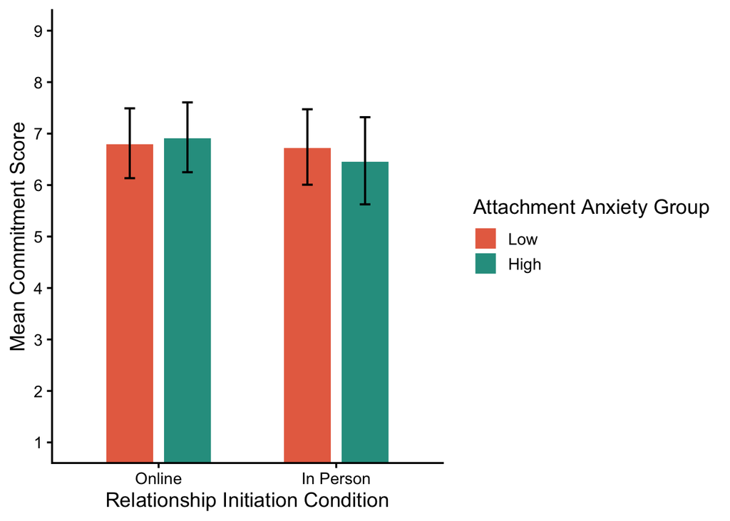

```r
p_anxiety_bar <- ggplot(
  as.data.frame(emmeans(a2_commitment_anxiety, ~ condition * ECRS_anxiety_msplit)),
  aes(
    x = condition,
    y = emmean,
    fill = ECRS_anxiety_msplit
  )
) +
  geom_col(
    position = position_dodge(width = 0.65),
    width = 0.55,
    color = "white"
  ) +
  geom_errorbar(
    aes(
      ymin = lower.CL,
      ymax = upper.CL
    ),
    position = position_dodge(width = 0.65),
    width = 0.12,
    linewidth = 0.7
  ) +
  labs(
    x = "Relationship Initiation Condition",
    y = "Mean Commitment Score",
    fill = "Attachment Anxiety Group"
  ) +
  scale_fill_manual(
    values = c(
      "Low" = "#E76F51",
      "High" = "#2A9D8F"
    )
  ) +
  scale_y_continuous(
    breaks = seq(1, 9, 1)
  ) +
  coord_cartesian(
    ylim = c(1, 9)
  ) +
  theme_classic(
    base_size = 14
  )

p_anxiety_bar
```

## The figure shows estimated commitment scores by relationship initiation condition (online vs. in-person) and attachment anxiety group (low vs. high). Error bars represent 95% confidence intervals.

### Commitment (ECRS Avoidance) Interaction Plot

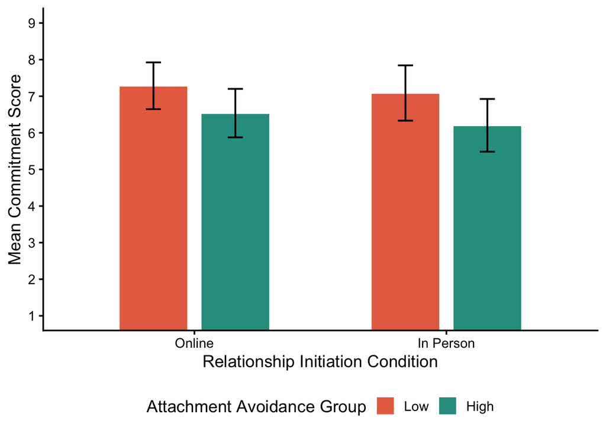

```r
p_avoidance_bar <- ggplot(
  as.data.frame(emmeans(a3_commitment_avoidance, ~ condition * ECRS_avoidance_msplit)),
  aes(
    x = condition,
    y = emmean,
    fill = ECRS_avoidance_msplit
  )
) +
  geom_col(
    position = position_dodge(width = 0.65),
    width = 0.55,
    color = "white"
  ) +
  geom_errorbar(
    aes(
      ymin = lower.CL,
      ymax = upper.CL
    ),
    position = position_dodge(width = 0.65),
    width = 0.12,
    linewidth = 0.7
  ) +
  labs(
    x = "Relationship Initiation Condition",
    y = "Mean Commitment Score",
    fill = "Attachment Avoidance Group"
  ) +
  scale_fill_manual(
    values = c(
      "Low" = "#E76F51",
      "High" = "#2A9D8F"
    )
  ) +
  scale_y_continuous(
    breaks = seq(1, 9, 1)
  ) +
  coord_cartesian(
    ylim = c(1, 9)
  ) +
  theme_classic(
    base_size = 14
  ) +
  theme(
  legend.position = "bottom")

p_avoidance_bar
```

The figure shows estimated commitment scores by relationship initiation condition (online vs. in-person) and attachment avoidance group (low vs. high). Error bars represent 95% confidence intervals. ### Export Figures

```r
if (!dir.exists("figures")) {
  dir.create("figures")
}

ggsave(
  filename = "figures/total_ecrs_interaction_plot.svg",
  plot = p_total_ecrs_bar,
  width = 7,
  height = 5
)

ggsave(
  filename = "figures/anxiety_interaction_plot.svg",
  plot = p_anxiety_bar,
  width = 7,
  height = 5
)

ggsave(
  filename = "figures/avoidance_interaction_plot.svg",
  plot = p_avoidance_bar,
  width = 7,
  height = 5
)
```